# Homework 2

TJ Sipin

2022-07-06

## Problem 1 (Statistical thinking).

1. Consider $\text{Cov}(\textbf{A}y) = \textbf{A}\text{Cov}(y)\textbf{A}^T,$ where $\textbf{A} = (X^T X)^{-1} X^T$ and $y = \beta X + \epsilon$. Taking the notation
   $$\hat \beta = (X^T X)^{-1} X^T y
   ,$$
   we have
   $$\begin{align}
   \text{Cov}(\hat \beta ) &= \text{Cov}((X^T X)^{-1} X^T y) \\
   &= \text{Cov}((X^T X)^{-1} X^T (X \beta + \epsilon)) \\
   &= \text{Cov}((X^T X)^{-1} X^T X \beta + (X^T X)^{-1} X^T
   \epsilon)\\
   &= \text{Cov} (I \beta + (X^T X)^{-1} X^T \epsilon)\\
   &= \text{Cov} (X^T X)^{-1} X^T \epsilon) \\
   &= \text{Cov}(\textbf{A}\epsilon) \\
   &= \textbf{A}\text{Cov}(\epsilon)\textbf{A}^T \\
   &= (X^T X)^{-1} X^T \sigma^2 ((X^T X)^{-1} X^T)^T \\
   &= \sigma^2 (X^T X)^{-1} X^T X \left ((X^T X)^{-1} \right )^T \\
   &= \sigma^2 (X^T X)^{-1}.
   \end{align}$$

The variance of $\hat\beta_1$ is given by the second diagonal of the above matrix. That is,

$$(i) \qquad
\text{Var}(\hat \beta_1 ) = \left [ \sigma^2 (X^T X)^{-1}\right ]_{2,2}.$$

2. Splitting the possible range of $x$ into 100 mutually exclusive windows and collecting the equal amount of sample from each slot is more efficient in terms of estimating $\beta_1$. So when we split the possible range of $x$ into 100 *mutually exclusive* windows, then we decrease variance of $x$, which in turn, decreases the variance of $\hat\beta$, as we see in $(i)$.

## Problem 2 (Prediction and confidence intervals)

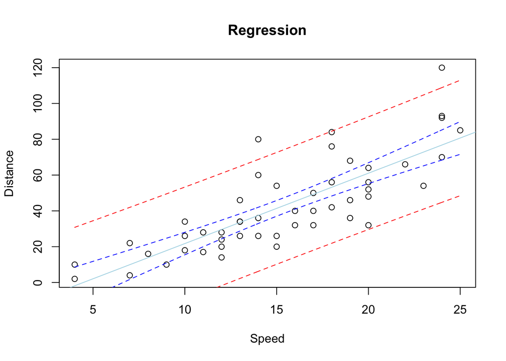

```r
# Regression for cars data
lm.out <- lm(dist ~ speed, data = cars)

# create new predictor
newx = seq(min(cars$speed), max(cars$speed), by = 0.1)

# get confidence interval for each element in newx
conf_interval <- predict(lm.out,
                         newdata=data.frame(speed=newx),
                         interval = "confidence",
                         level = 0.95)

# get prediction interval for each element in newx
pred_interval <- predict(lm.out,
                         newdata = data.frame(speed=newx),
                         interval = "prediction",
                         level = 0.95)
# plot data points
plot(cars$speed, cars$dist,
     main = "Regression",
     xlab = "Speed",
     ylab = "Distance")

# regression line
abline(lm.out, col = 'lightblue')

# add lower end of CI
lines(newx, conf_interval[,2], col = 'blue', lty = 2)
# add upper end of CI
lines(newx, conf_interval[,3], col = 'blue', lty = 2)
# add lower end of PI
lines(newx, pred_interval[,2], col = 'red', lty = 2)
# add upper end of PI
lines(newx, pred_interval[,3], col = 'red', lty = 2)
```

The prediction interval is wider than the confidence interval since the confidence interval pertains to the median (at a 95% level), while the prediction interval pertains to all points in the relationship of distance and speed within a 95% level.

## Problem 3 (Weighted least squares).

1. Derive the BLUE of $\beta_0$ and $\beta_1$ for

$$y_i \sim^{\text{indep}} N(\beta_0 + \beta_1 x_i, x_i^2 \sigma^2), \qquad
i = 1, \dots, n.$$

*Solution.* Here, we have $\epsilon \sim N(0, \sigma^2 \textbf{V}),$ where $\textbf V = x_i^2I, \text{ for } i = 1,\dots, n$. The OLS estimator is BLUE when $\epsilon \sim (0, \sigma^2 I).$ Since $\textbf V$ can be decomposed as $\textbf V = (x_i I) (x_i I)^T$, it follows that

$$\text{Cov}((x_i I)^{-1} \epsilon) = \sigma^2 (x_iI)^{-1} x_i I (x_i I)^T
((x_i I )^{-1})^T = \sigma^2 I.$$

This allows us to change the OLS problem to

$$(x_i I)^{-1}Y = (x_i I)^{-1}X \beta + (x_i I)^{-1} \epsilon, \quad (x_i
I)^{-1} \sim N(0, \sigma^2 I).$$

Thus, we can get BLUE from the OLS estimator from the changed problem:

$$(ii)
\begin{aligned}
\hat\beta &= (X^T((x_i I)^T)^{-1} (x_i I)^{-1} X)^{-1}((x_i I)^{-1}
X)^T (x_i I)^{-1} Y \\
&= (X^T (x_i I x_i I^T)^{-1} X)^{-1} X^T (x_i I x_i I^T)^{-1} Y \\
&= (X^T (x_i I x_i I^T)^{-1} X)^{-1} X^T (x_i I x_i I^T)^{-1} Y \\
&= (X^T(x_i ^2 I)^{-1} X)^{-1} X^T(x_i^2 I)^{-1} Y,
\end{aligned}$$

as long as $X^T (x_i^2 I)^{-1}X$ is nonsingular. That is, if $n > 1$ and at least one $x_i \neq 0$ . The BLUE of $\beta_0$ is the first row of the above matrix $(ii)$ and the BLUE of $\beta_1$ is the second row.

```r
# library(matlib)
set.seed(2022)
x = rnorm(20, 30, 5)
y = rnorm(20, 40, 5)


lm.out.3b = lm(y ~ x)
xm = matrix(c(rep(1, times = 20), x), nrow = 20)
ym = as.matrix(y)
q  = diag(x = x^2, nrow = 20, ncol = 20)

beta.hat = solve(t(xm)%*%solve(q)%*%xm)%*%t(xm)%*%solve(q)%*%ym
beta.hat
```

```
##            [,1]
## [1,] 35.8811172
## [2,]  0.1709089
```

```r
lm.out.3c = lm(y ~ x, weights = 1/(x**2))
lm.out.3c
```

```
##
## Call:
## lm(formula = y ~ x, weights = 1/(x^2))
##
## Coefficients:
## (Intercept)            x
##     35.8811       0.1709
```

The results are the same as the results in (b). Here, the `weights =` option is giving us the inverse of $V$. This is since $Y \sim N(\mu, V \sigma^2) \implies \frac{Y}{V} \sim N(\mu, \sigma^2)$.

## Problem 4 (Wheezing data).

```r
wheeze <- read.csv('data/wheeze_wmiss.csv')
wheeze %>% head()
```

```
##   case t wheeze kingston age smoke
## 1    1 1      1        0   9     0
## 2    1 2      1        0  10     0
## 3    1 3      1        0  11     0
## 4    1 4      0        0  12     0
## 5    2 1      1        1   9     1
## 6    2 2      1        1  10     2
```

```r
summary(wheeze)
```

```
##       case             t            wheeze          kingston
##  Min.   : 1.00   Min.   :1.00   Min.   :0.0000   Min.   :0.0000
##  1st Qu.: 4.75   1st Qu.:1.75   1st Qu.:0.0000   1st Qu.:0.0000
##  Median : 8.50   Median :2.50   Median :0.0000   Median :0.0000
##  Mean   : 8.50   Mean   :2.50   Mean   :0.2969   Mean   :0.4531
##  3rd Qu.:12.25   3rd Qu.:3.25   3rd Qu.:1.0000   3rd Qu.:1.0000
##  Max.   :16.00   Max.   :4.00   Max.   :1.0000   Max.   :1.0000
##
##       age            smoke
##  Min.   : 9.00   Min.   :0.00
##  1st Qu.: 9.75   1st Qu.:0.00
##  Median :10.50   Median :1.00
##  Mean   :10.50   Mean   :0.78
##  3rd Qu.:11.25   3rd Qu.:1.00
##  Max.   :12.00   Max.   :2.00
##                  NA's   :14
```

```r
wheeze <- wheeze %>%
  mutate(smoke = as.factor(smoke))

# %>%
#   mutate(wheeze = as.factor(wheeze)) %>%
#   mutate(kingston = as.factor(kingston))


wheeze_binom <- glm(wheeze ~ . - t, data = wheeze, family = "binomial")

summary(wheeze_binom)
```

```
##
## Call:
## glm(formula = wheeze ~ . - t, family = "binomial", data = wheeze)
##
## Deviance Residuals:
##     Min       1Q   Median       3Q      Max
## -1.3820  -0.8890  -0.6402   1.2748   1.7231
##
## Coefficients:
##             Estimate Std. Error z value Pr(>|z|)
## (Intercept)  2.00511    3.18201   0.630    0.529
## case         0.03012    0.07016   0.429    0.668
## kingston     0.61103    0.64974   0.940    0.347
## age         -0.25530    0.30083  -0.849    0.396
## smoke1      -1.16160    0.72795  -1.596    0.111
## smoke2      -0.67572    0.99893  -0.676    0.499
##
## (Dispersion parameter for binomial family taken to be 1)
##
##     Null deviance: 62.687  on 49  degrees of freedom
## Residual deviance: 58.756  on 44  degrees of freedom
##   (14 observations deleted due to missingness)
## AIC: 70.756
##
## Number of Fisher Scoring iterations: 4
```

The coefficients for `smoke1` and `smoke2` both have a p-value of greater than 0.05, thus smoking is not significant at the 95% level.

```r
library(lme4)
wheeze_binom_random_intercept <- glmer(wheeze ~ kingston + smoke + (1|case), family = 'binomial', data = wheeze)
summary(wheeze_binom_random_intercept)$coefficients
```

```
##               Estimate Std. Error    z value  Pr(>|z|)
## (Intercept) -0.8462974  0.9107001 -0.9292822 0.3527429
## kingston     0.9032460  1.0581880  0.8535780 0.3933389
## smoke1      -1.0606774  0.9053678 -1.1715431 0.2413805
## smoke2      -1.1177135  1.3483172 -0.8289692 0.4071218
```

The p-values are 0.24 and 0.40 for the random intercept model, compared to 0.11 and 0.50 from the GLM. The p-value for smoke1 gets bigger, while the p-value for smoke2 gets smaller.

# Appendix: All code for this report

```r
knitr::opts_chunk$set(echo = TRUE)
library(dplyr)
# Regression for cars data
lm.out <- lm(dist ~ speed, data = cars)

# create new predictor
newx = seq(min(cars$speed), max(cars$speed), by = 0.1)

# get confidence interval for each element in newx
conf_interval <- predict(lm.out,
                         newdata=data.frame(speed=newx),
                         interval = "confidence",
                         level = 0.95)

# get prediction interval for each element in newx
pred_interval <- predict(lm.out,
                         newdata = data.frame(speed=newx),
                         interval = "prediction",
                         level = 0.95)
# plot data points
plot(cars$speed, cars$dist,
     main = "Regression",
     xlab = "Speed",
     ylab = "Distance")

# regression line
abline(lm.out, col = 'lightblue')

# add lower end of CI
lines(newx, conf_interval[,2], col = 'blue', lty = 2)
# add upper end of CI
lines(newx, conf_interval[,3], col = 'blue', lty = 2)
# add lower end of PI
lines(newx, pred_interval[,2], col = 'red', lty = 2)
# add upper end of PI
lines(newx, pred_interval[,3], col = 'red', lty = 2)
# library(matlib)
set.seed(2022)
x = rnorm(20, 30, 5)
y = rnorm(20, 40, 5)


lm.out.3b = lm(y ~ x)
xm = matrix(c(rep(1, times = 20), x), nrow = 20)
ym = as.matrix(y)
q  = diag(x = x^2, nrow = 20, ncol = 20)

beta.hat = solve(t(xm)%*%solve(q)%*%xm)%*%t(xm)%*%solve(q)%*%ym
beta.hat
lm.out.3c = lm(y ~ x, weights = 1/(x**2))
lm.out.3c
wheeze <- read.csv('data/wheeze_wmiss.csv')
wheeze %>% head()
summary(wheeze)
wheeze <- wheeze %>%
  mutate(smoke = as.factor(smoke))

# %>%
#   mutate(wheeze = as.factor(wheeze)) %>%
#   mutate(kingston = as.factor(kingston))


wheeze_binom <- glm(wheeze ~ . - t, data = wheeze, family = "binomial")

summary(wheeze_binom)
library(lme4)
wheeze_binom_random_intercept <- glmer(wheeze ~ kingston + smoke + (1|case), family = 'binomial', data = wheeze)
summary(wheeze_binom_random_intercept)$coefficients
```